# TP Machine Learning en Aplicaciones Espaciales

FLACSO Argentina

Mateo W. Racca

12/07/23

## ¿Qué es esto?

Este es el trabajo final del módulo Machine Learning en Aplicaciones Espaciales a cargo del Dr. Germán Rosati en el marco del Posgrado en Big Data y Desarrollo Territorial de FLACSO Argentina (2020).

El objetivo principal es generar un modelo que permita valorizar los departamentos en venta (valor en dólares/metro cuadrado) de la Ciudad Autónoma de Buenos Aires. Para eso se va a trabajar con una regresión lineal, un árbol basado en CART y un ensemble. Luego, se van a comparar performances y se seleccionará el modelo más adecuado para abordar el problema en cuestión.

## ¿Qué datos se van a usar?

El relevamiento se realizaba todos los años, desde 2001 y el dataset tiene información sobre los precios totales y por metro cuadrado (en U$D).

## ¿Cuál es la variable a predecir?

En este caso, se podría predecir el precio total del departamento como así también el precio por metro cuadrado (ambos en dólares). Este trabajo se va a enfocar en el precio en dólares por metro cuadrado (*USD/M2*).

### Paquetes y carga de datos

Los paquetes a utilizar son:

```r
library(caret)
library(rpart)
library(tidyverse)
library(sf)
library(viridis)
library(ggpubr)
library(iml)
library(pdp)

#crear paleta de colores
colorcito <- c("#cfa8e6", "#bae1ff", "#a8e6cf", "#ffd3b6", "#dcedc1", "#ffaaa5", "#ffd86c", "#e2caf0", "#d5edff", "#d8b9eb", "#c7e7ff", "#b9ebd8", "#ffdbc4", "#e3f0cd", "#ffbbb7", "#ffe59f")
```

El dataset está disponible en el repositorio de github, al igual que el código en formato .rmd y el resultado en .html.

```r
#lectura del dataset
data <- read.delim2("deptos_2014.csv", sep = ";", comment.char = "", check.names = F, encoding = "Latin-1")

#renombrar columna con error de lectura
names(data)[names(data) == "BA\xc3.OS"] <- "BAÑOS"
```

### Análisis de variables y limpieza de datos

Antes de empezar es necesario conocer los datos originales para luego limpiar y/o reorganizar el dataset.

```r
str(data)
```

```
## 'data.frame':    12724 obs. of  17 variables:
##  $ CALLE     : chr  "11 DE SEPTIEMBRE DE 1888" "11 DE SEPTIEMBRE DE 1888" "11 DE SEPTIEMBRE DE 1888" "11 DE SEPTIEMBRE DE 1888" ...
##  $ NUMERO    : int  700 800 900 900 900 900 900 1000 1100 1200 ...
##  $ M2        : int  560 126 109 150 270 350 362 121 193 220 ...
##  $ DOLARES   : int  1270000 295000 320000 400000 950000 880000 470000 295000 565000 620000 ...
##  $ U_S_M2    : chr  "2267.9" "2341.3" "2935.8" "2666.7" ...
##  $ AMBIENTES : int  5 4 4 4 4 4 4 4 5 4 ...
##  $ ANTIGUEDAD: int  20 45 20 37 30 30 37 NA 37 10 ...
##  $ ORIENT    : chr  "FRENTE" "S/D" "FRENTE" "FRENTE" ...
##  $ BAULERA   : chr  "Si" "No" "Si" "Si" ...
##  $ COCHERA   : chr  "Si" "Si" "Si" "Si" ...
##  $ BAÑOS     : int  4 0 3 2 3 0 0 0 4 0 ...
##  $ LAVADERO  : chr  "No" "No" "Si" "Si" ...
##  $ TERRAZA   : chr  "Si" "No" "Si" "Si" ...
##  $ BARRIO    : chr  "PALERMO" "PALERMO" "PALERMO" "PALERMO" ...
##  $ COMUNA    : int  14 14 14 14 14 14 14 14 14 14 ...
##  $ LON       : chr  "-58.4395225166253" "-58.4402560763357" "-58.4413206426802" "-58.4413206426802" ...
##  $ LAT       : chr  "-34.5706919299279" "-34.5703125198249" "-34.5694871096261" "-34.5694871096261" ...
```

En cuanto a valores perdidos:

```r
head(is.na(data), n=15)
```

```
##    CALLE NUMERO    M2 DOLARES U_S_M2 AMBIENTES ANTIGUEDAD ORIENT BAULERA
## 1  FALSE  FALSE FALSE   FALSE  FALSE     FALSE      FALSE  FALSE   FALSE
## 2  FALSE  FALSE FALSE   FALSE  FALSE     FALSE      FALSE  FALSE   FALSE
## 3  FALSE  FALSE FALSE   FALSE  FALSE     FALSE      FALSE  FALSE   FALSE
## 4  FALSE  FALSE FALSE   FALSE  FALSE     FALSE      FALSE  FALSE   FALSE
## 5  FALSE  FALSE FALSE   FALSE  FALSE     FALSE      FALSE  FALSE   FALSE
## 6  FALSE  FALSE FALSE   FALSE  FALSE     FALSE      FALSE  FALSE   FALSE
## 7  FALSE  FALSE FALSE   FALSE  FALSE     FALSE      FALSE  FALSE   FALSE
## 8  FALSE  FALSE FALSE   FALSE  FALSE     FALSE       TRUE  FALSE   FALSE
## 9  FALSE  FALSE FALSE   FALSE  FALSE     FALSE      FALSE  FALSE   FALSE
## 10 FALSE  FALSE FALSE   FALSE  FALSE     FALSE      FALSE  FALSE   FALSE
## 11 FALSE  FALSE FALSE   FALSE  FALSE     FALSE       TRUE  FALSE   FALSE
## 12 FALSE  FALSE FALSE   FALSE  FALSE     FALSE       TRUE  FALSE   FALSE
## 13 FALSE  FALSE FALSE   FALSE  FALSE     FALSE       TRUE  FALSE   FALSE
## 14 FALSE  FALSE FALSE   FALSE  FALSE     FALSE       TRUE  FALSE   FALSE
```

[output cut: 17 more lines]

Algunas variables están configuradas de manera poco conveniente. Otras no son necesarias, como es el caso de las variables *BARRIO*, *LAT* (latitud) y *LON* (longitud) ya que hacen referencia a la ubicación espacial de las propiedades y contamos con información relacionada en las variables *CALLE*, *COMUNA* y *NÚMERO*. Por otro lado, la variable *DOLARES* no será considerada ya que expresa el precio total de los departamentos en venta y se va a utilizar como referencia/variable objetiva *USD_M2*.

```r
data <- data %>%
  select(-BARRIO, -LAT, -LON, -DOLARES) %>%
  rename(ORIENTACION = ORIENT,
         USD_M2 = U_S_M2)
```

#### Antigüedad

Como la variable acerca de la antigüedad de los departamentos presenta valores perdidos, es pertinente visualizarla a través de un boxplot.

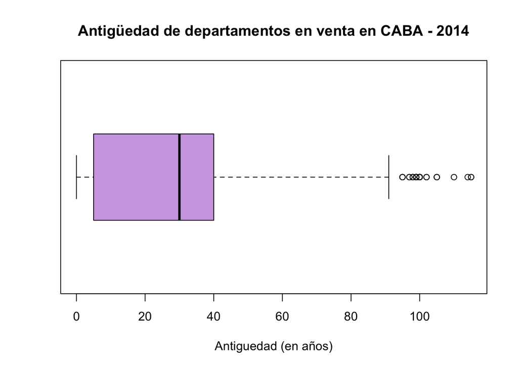

```r
boxplot(x = data$ANTIGUEDAD, col = colorcito, main = "Antigüedad de departamentos en venta en CABA - 2014", xlab="Antiguedad (en años)", horizontal = TRUE)
```

Ahora las estadísticas de resumen:

```r
summary(data$ANTIGUEDAD)
```

```
##    Min. 1st Qu.  Median    Mean 3rd Qu.    Max.    NA's
##    0.00    5.00   30.00   28.35   40.00  115.00    2782
```

Se puede observar que el promedio de antigüedad es de 28 años, mientras que el valor del tercer quartil es de 40 años de antigüedad y el máximos es de 115 años. Hay 2782 departamentos en el dataset que tienen valores perdidos en esta variable.

#### Ajuste de variables

Es necesario entonces reordenar y recodificar algunas variables:

```r
data <- data %>%
  mutate(
    BAÑOS = case_when(
      BAÑOS == 0 ~ "S/D",
      BAÑOS == 1 ~ "1",
      BAÑOS == 2 ~ "2",
      BAÑOS >= 3 ~ "3 o +"),
    AMBIENTES = case_when(
      AMBIENTES <= 1 ~ "1",
      AMBIENTES == 2 ~ "2",
      AMBIENTES == 3 ~ "3",
      AMBIENTES > 3 ~ "mas de 3"),
    COMUNA = as.factor(COMUNA),
    ANTIGUEDAD = as.character(ANTIGUEDAD),
    ANTIGUEDAD = case_when(
      ANTIGUEDAD == 'A ESTRENAR' ~ '0',
      is.na(ANTIGUEDAD) ~ '0',
      TRUE ~ ANTIGUEDAD),
    ANTIGUEDAD = as.numeric(ANTIGUEDAD),
    USD_M2 = as.numeric(USD_M2),
    CALLE = as.factor(CALLE),
    ORIENTACION = as.factor(ORIENTACION)) %>%
  drop_na()
```

#### Precio en USD por metro cuadrado

El precio en dólares por metro cuadrado de los departamentos es la variable a predecir. Para entenderla mejor, es pertinente ver los datos en un boxplot:

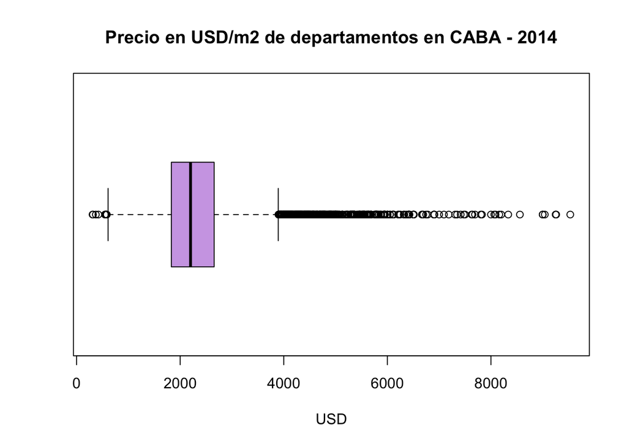

```r
boxplot(x = data$USD_M2, col = colorcito, main = "Precio en USD/m2 de departamentos en CABA - 2014", xlab="USD", horizontal = TRUE)
```

Las estadísticas de resumen:

```r
summary(data$USD_M2)
```

```
##    Min. 1st Qu.  Median    Mean 3rd Qu.    Max.
##     308    1829    2200    2321    2655    9531
```

#### Ubicación de los departamentos

En cuanto al número de departamentos disponibles por comuna:

```r
sumatoria_comunas <- data %>%
  group_by(COMUNA) %>%
  summarise(sumatoria = n()) %>%
  arrange(desc(sumatoria))
```

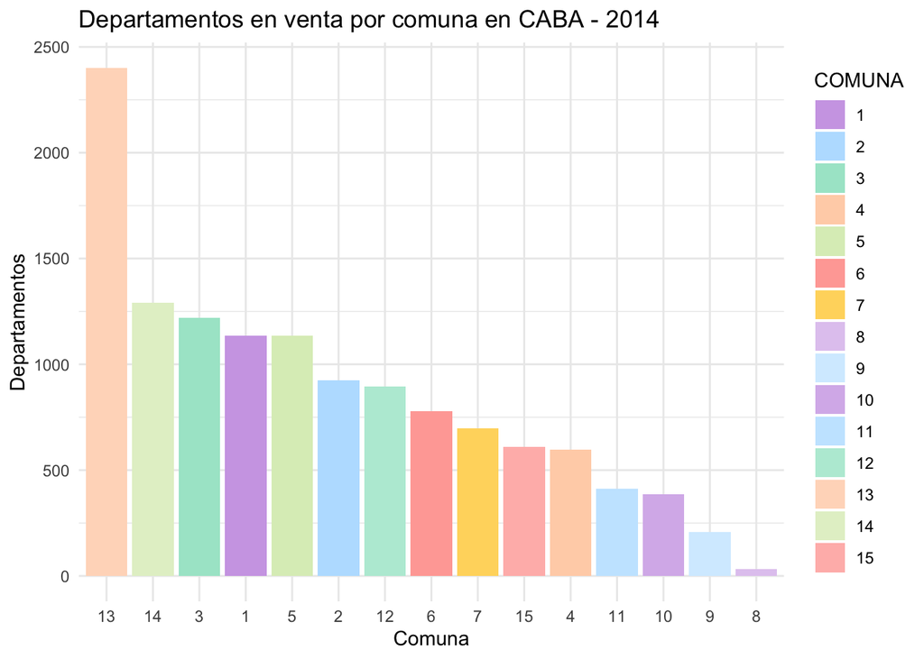

```r
ggplot(data = sumatoria_comunas, aes(x = reorder(COMUNA, (-sumatoria)), y = sumatoria, fill = COMUNA)) +
  geom_bar(stat = "identity", position = "dodge") +
  labs(title="Departamentos en venta por comuna en CABA - 2014",
  x="Comuna",
  y= "Departamentos") +
  scale_fill_manual(values = colorcito) +
  theme_minimal()
```

Se toman los datos geográficos sobre las comunas, para luego poder ubicar las propiedades en el mapa:

```r
comunas <- st_read("https://bitsandbricks.github.io/data/CABA_comunas.geojson") %>%
  rename(COMUNA = comunas) %>%
  select(-barrios) %>%
  mutate(COMUNA = as.factor(COMUNA))

data_comunas <- data %>%
  group_by(COMUNA) %>%
  count() %>%
  rename(TOTAL_DEPTOS = n)

mapa <- left_join(comunas, data_comunas)
```

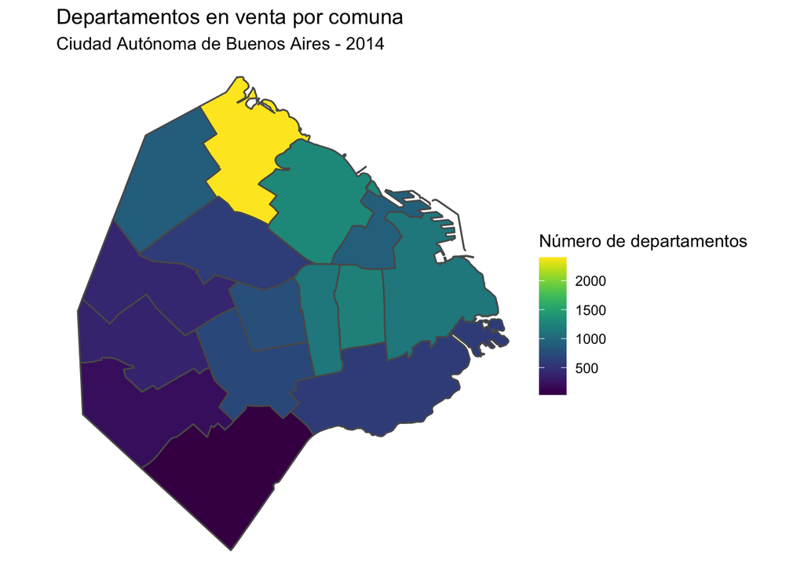

```r
ggplot() +
  geom_sf(data = mapa, aes(fill = TOTAL_DEPTOS)) +
  scale_fill_viridis() +
  labs (title= "Departamentos en venta por comuna", subtitle = "Ciudad Autónoma de Buenos Aires - 2014", fill = "Número de departamentos") +
  theme_void()
```

## Los modelos

Tal como se planteó al principio y con el objetivo de generar un modelo que permita valorizar los departamentos en venta de la Ciudad Autónoma de Buenos Aires (en *USD/M2*). Se trabajará con una regresión lineal, un árbol basado en CART y un ensemble.

El primer paso, clave para la replicabilidad del caso y de los modelos, es fijar la aleatoriedad con la función *set.seed()*:

```r
set.seed(221)
```

*createDataPartition()* nos permite generar índices para la partición:

```r
tr_index <- createDataPartition(y = data$USD_M2,
                                p = 0.7,
                                list = FALSE)
```

Dónde *y* representa la variable a predecir y *p* el temaño de la muestra de entrenamiento (70% del dataset original).

*slice()* nos permite tomar el dataset original y dividirlo en uno de entrenamiento (*train*) y otro de evaluación (*test*):

```r
train <- data %>% slice(tr_index)

test <- data %>% slice(-tr_index)
```

Con el objetivo de estimar el error de generalización, se utiliza el método de *Validación Cruzada* (en inglés, *Cross Validation*). Para eso se toman los datos de entrenamiento:

```r
cv_index <- createFolds(y = train$USD_M2,
                        k = 5,
                        list = TRUE,
                        returnTrain = TRUE)
```

Y se definen los parámetros de control de ajuste:

```r
fitControl <- trainControl(
        index = cv_index,
        method = "cv",
        number = 5)
```

### Regresión lineal múltiple

El primer modelo a entrenar/utilizar es uno de regresión lineal múltiple. Para eso:

```r
lm_fit <- train(USD_M2~.,
                data = train,
                method = "lm",
                trControl = fitControl)
```

Ahora, vamos a los resultados:

```r
lm_fit
```

```
## Linear Regression
##
## 8908 samples
##   12 predictor
##
## No pre-processing
## Resampling: Cross-Validated (5 fold)
## Summary of sample sizes: 7128, 7126, 7126, 7126, 7126
## Resampling results:
##
##   RMSE    Rsquared  MAE
##   570.05  0.488289  395.846
##
## Tuning parameter 'intercept' was held constant at a value of TRUE
```

### CART: Árbol de decisión

En segunda instancia, se procede a entrenar un modelo CART (árbol de decisión). Primero, se establecen los hiperparámetros:

```r
grid <- expand.grid(maxdepth=c(1, 3, 9, 18, 27))
```

Luego, se entrena el modelo:

```r
cart_dptos <- train(USD_M2 ~ . ,
                 data = train,
                 method = "rpart2",
                 trControl = fitControl,
                 tuneGrid = grid)
```

Ahora, vamos a los resultados:

```r
cart_dptos
```

```
## CART
##
## 8908 samples
##   12 predictor
##
## No pre-processing
## Resampling: Cross-Validated (5 fold)
## Summary of sample sizes: 7128, 7126, 7126, 7126, 7126
## Resampling results across tuning parameters:
##
##   maxdepth  RMSE      Rsquared   MAE
##    1        739.1869  0.1285874  522.0861
##    3        717.0831  0.1798999  502.5303
##    9        665.4680  0.2935121  461.4912
##   18        650.7761  0.3246120  448.6996
##   27        650.7761  0.3246120  448.6996
##
## RMSE was used to select the optimal model using the smallest value.
## The final value used for the model was maxdepth = 18.
```

### Random Forest

Finalmente, el tercer modelo a entrenar es un modelo de ensemble, en este caso random forest.

```r
grid_rf <- expand.grid(mtry = c(15, 30, 60),
                       min.node.size = c(1, 3, 5),
                       splitrule = "extratrees")
```

```r
rf_fit <-  train(USD_M2 ~ . ,
                 data = train,
                 method = "ranger",
                 trControl = fitControl,
                 tuneGrid = grid_rf)
```

Ahora, vamos a los resultados:

```r
rf_fit
```

```
## Random Forest
##
## 8908 samples
##   12 predictor
##
## No pre-processing
## Resampling: Cross-Validated (5 fold)
## Summary of sample sizes: 7128, 7126, 7126, 7126, 7126
## Resampling results across tuning parameters:
##
##   mtry  min.node.size  RMSE      Rsquared   MAE
##   15    1              618.8753  0.4602487  424.6448
##   15    3              619.7727  0.4576618  425.7325
##   15    5              619.7893  0.4581966  425.4799
##   30    1              589.3619  0.4836190  403.3552
##   30    3              589.3220  0.4838530  403.5542
##   30    5              589.3083  0.4838256  403.6338
##   60    1              565.1769  0.5083195  385.0753
##   60    3              565.4421  0.5077273  385.3055
##   60    5              565.8700  0.5071867  385.2834
##
## Tuning parameter 'splitrule' was held constant at a value of extratrees
## RMSE was used to select the optimal model using the smallest value.
## The final values used for the model were mtry = 60, splitrule = extratrees
##  and min.node.size = 1.
```

## Comparando Modelos

Ahora que los modelos están entrenados, se va a comparar su performance en el set de datos de testeo. Para eso se crea una función de evaluación:

```r
eval_regresion <- function(model, test_set, y){
  preds <- predict(model, test_set)
  metrics <- postResample(preds, y)
  return(metrics)
  }
```

Ahora se listan los modelos para identificarlos fácilmente:

```r
models <- list(lm = lm_fit,
               cart = cart_dptos,
               rf = rf_fit)
```

Y se sacan las métricas:

```r
model_metrics <- models %>%
        map(eval_regresion, test, test$USD_M2)
```

Ahora se puede observar la evaluación final de los modelos:

```r
model_metrics
```

```
## $lm
##        RMSE    Rsquared         MAE
## 576.9401465   0.4945313 395.9457989
##
## $cart
##        RMSE    Rsquared         MAE
## 662.2502347   0.3310382 450.6148648
##
## $rf
##        RMSE    Rsquared         MAE
## 572.2118573   0.5246451 383.5498125
```

Respecto a la performance de los tres modelos:

- *RMSE* o *raíz cuadrada del error cuadrático medio*: los valores alcanzados por los modelos *lm* y *rf* son similares aunque el ensemble resulta algo más acertado.
- *Rsquared* o *R Cuadrado*: *rf* tiene mejor performance.
- *MAE* o *error absoluto medio*: en este apartado también el modelo *rf* logró el mejor resultado.

Los resultados en un gráfico:

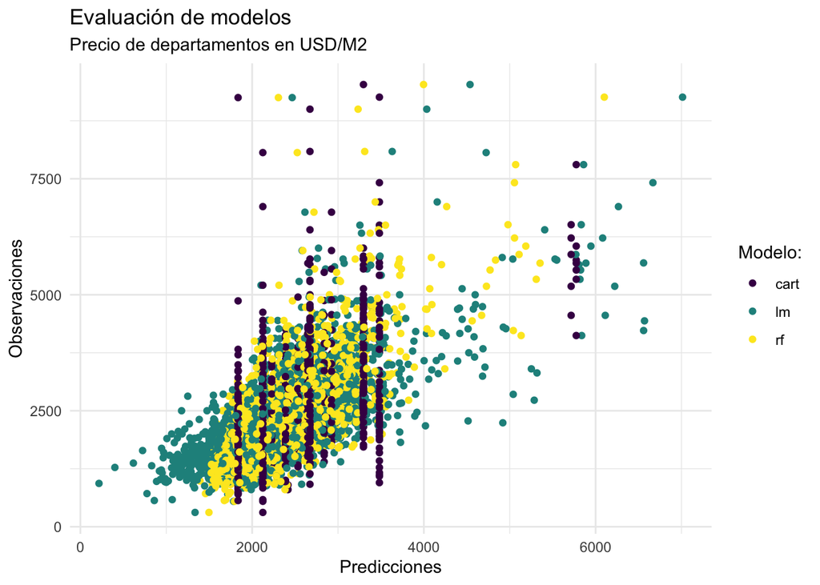

```r
model_preds <- models %>%
        map(predict, test) %>%
        as_tibble() %>%
        mutate(y = test$USD_M2)

final_model_preds <- model_preds %>%
  pivot_longer(!y, names_to = "modelo", values_to = "pred")


ggplot(final_model_preds) +
  geom_point(aes(x = pred, y = y, color = modelo)) +
  labs(title = "Evaluación de modelos",
       subtitle = "Precio de departamentos en USD/M2",
       x = "Predicciones",
       y = "Observaciones",
       color = "Modelo:") +
  scale_colour_viridis_d() +
  theme_minimal()
```

## Interpretable Machine Learning

La bibliografía y el material de clase aportan que para interpretar los modelos de machine learning hay diferentes herramientas. En este caso, se evaluará con: Variable Importance, Partial Dependence Plots (*PDP*) e Individual Conditional Expectation (*ICE*).

### Variable Importance

Identifica las variables de mayor importancia/peso sobre la variable a predecir.

```r
varimp <- function(data, y, model, loss='mse'){
  bool <- !names(data) %in% y
  X <- data[,bool]
  predic <- iml::Predictor$new(model, data=X, y=data[y])
  vi <- iml::FeatureImp$new(predic, loss='mse')
  return(vi)
  }
```

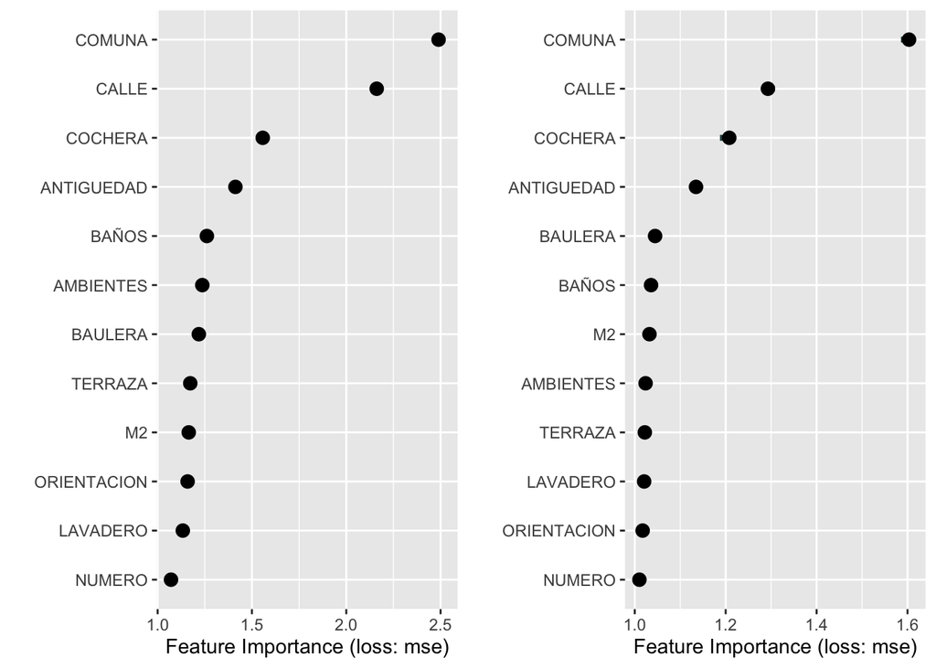

```r
ggarrange(plot(varimp(data = train, y = "USD_M2", model = rf_fit)),
          plot(varimp(data = test, y = "USD_M2", model = rf_fit)))
```

El plot de la izquierda corresponde a los datos de entrenamiento y el de la derecha a los de validación. Las variables que más ponderan en relación a la variable a predecir (*U$D/M2*) son:

- La comuna en la que se ubica el departamento.
- La calle sobre la que se encuetra.
- Si tiene o no cochera.
- La antigüedad del mismo.

El resto de las variables tienen una importancia menor.

### Partial Dependence Plots

Visualiza el efecto marginal de una o dos variables independientes sobre la variable que predijo un modelo. Estima cómo varía el valor de la variable a predecir (*y*) a medida que cambian los valores de las variables independientes (*x*).

Puede ser utilizado en variables cuantitativas, y como *ANTIGUEDAD* fue la variable numérica que más importancia tuvo en el análisis de *Variable Importance*:

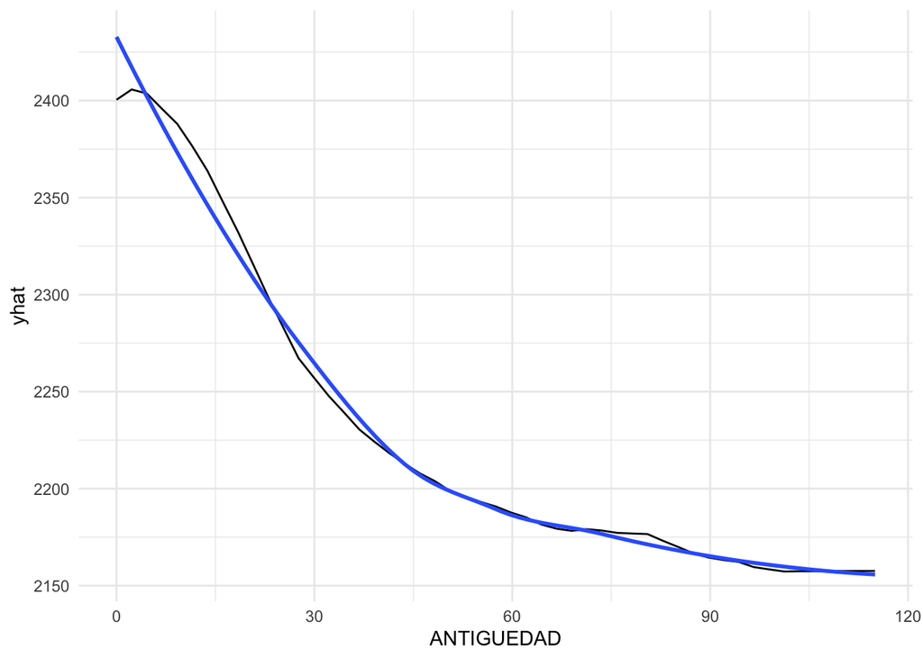

```r
rf_fit %>%
  partial(pred.var = "ANTIGUEDAD") %>%
  ggplot(aes(x = ANTIGUEDAD, y = yhat)) +
  geom_line() +
  geom_smooth(se = FALSE) +
  theme_minimal()
```

Tal como se puede observar, el *yhat* o valor predicho cae a medida que la variable *ANTIGUEDAD* tiene valores mayores. En color negro aparecen los valores normales y en azul suavizados.

### Individual Conditional Expectation

Visualiza una linea por instancia que muestra cómo cambia la predicción de la instancia a medida que cambia una característica.

En este caso:

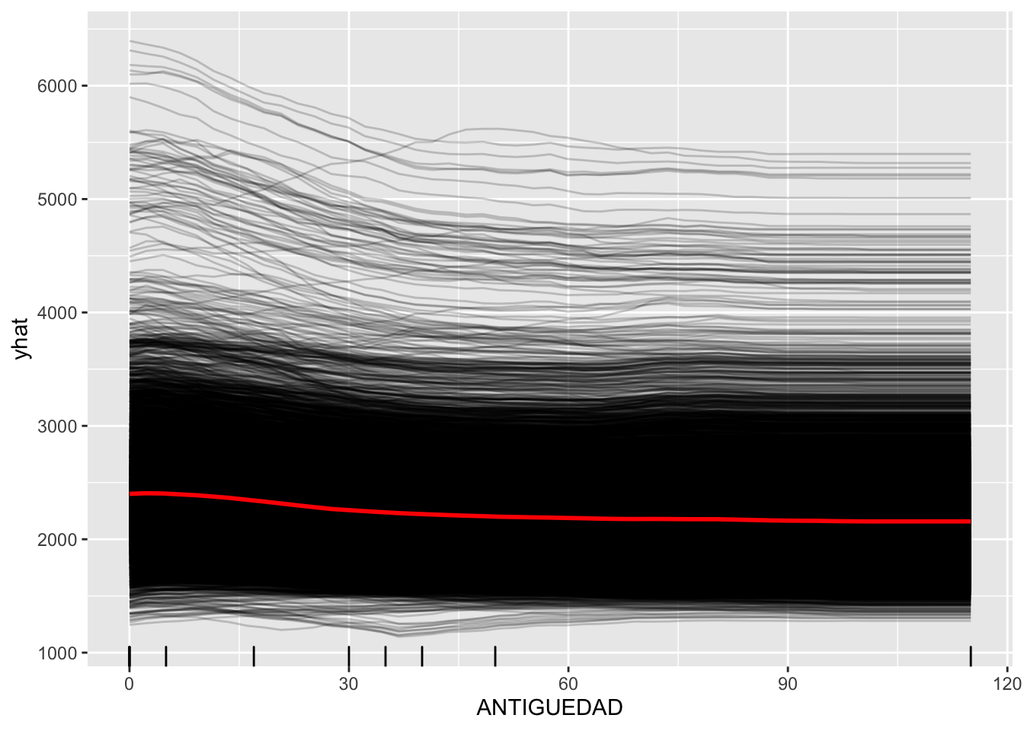

```r
ggarrange(partial(rf_fit, pred.var = "ANTIGUEDAD", plot = TRUE, ice = TRUE, rug = TRUE, plot.engine = "ggplot", alpha = 0.2))
```

El resultado es una línea por departamento a la venta (en negro) y una única línea de desempeño general (en rojo). La mayoría de los casos comparten un patron: a menor antigüedad mayor precio, aunque como se puede observar la pendiente no es abismal y en consecuencia la baja del precio tampoco. En algunos casos esto no se cumple y la antigüedad no es sinónimo de caída de precio mientras que en otros (sobre todo cuando el valor del metro cuadrado es mayor) los inmuebles pierden valor después de los primeros años.

El punto de quiebre se da al rededor de los 15 años de antigüedad, a partir de donde el precio según se puede observar cae de manera suave, pero progresiva y constante.

## Conclusiones

Ell objetivo de este trabajo es generar un modelo que permita valorizar los departamentos en venta (*U$S/M2*) en la Ciudad Autónoma de Buenos Aires.

Después de trabajar con una regresión lineal, un árbol de decisión (CART) y un modelo de ensemble (random forest) y de comparar sus performances random forest (*rf*) resultó el más adecuado para el problema en cuestión.

**¿Por qué?**:

- En cuanto al *RMSE*, el ensemble resulta algo más acertado que los demás modelos.
- En el valor de *Rsquared* el modelo rf tiene mejor performance.
- En el caso del *MAE*, rf también logró el mejor resultado.

Una vez seleccionado el modelo y para lograr mayor interpretabilidad del mismo se recurrió a análisis con *Variable Importance*, *Partial Dependence Plots* y también *Individual Conditional Expectation*. Esto fue clave para detectar las variables de mayor influencia sobre la variable a predecir, que son: *comuna, calle, cochera y antigüedad* y también para hacer foco en la influencia de esta última variable sobre el precio en dólares por metro cuadrado. A medida que la antigüedad es mayor el precio tiende a caer, y si bien no es el factor más determinante tiene una influencia marcada y progresiva.

Es importante destacar también que este modelo no es absoluto y que la variable a predecir es compleja. Si bien el modelo de ensemble tiene cierta complejidad hay muchísimos factores que quedan excluidos y que podrían ser relevantes como por ejemplo: el acceso a servicios básicos de salud, transporte y educación, a espacios verdes, a locales de compras esenciales y de actividades recreativas; los índices de contaminación del aire y sonora, y muchas otras cosas que escapan el alcance de los modelos entrenados y también de los datos con los que contamos.

Más allá de eso, la capacidad predictiva del modelo es (al menos) aceptable y puede resultar útil.